# Project 2: Gym Data Analysis

Jeet Patel

2025-03-23

## 📦 Task 1: Factor Setup

Convert key categorical variables into factors to ensure correct analysis.

```r
gymData <- read.csv("/Users/jeetpatel/Desktop/Project 2/gym2.csv")

gymData$Workout_Type <- as.factor(gymData$Workout_Type)
gymData$Experience_Level <- factor(gymData$Experience_Level, ordered = TRUE)
gymData$Gender <- as.factor(gymData$Gender)
gymData$bmi_class <- factor(gymData$bmi_class, ordered = TRUE)
```

### ✅ Interpretation

We transform variables like `Workout_Type`, `Experience_Level`, `Gender`, and `bmi_class` into factors so that R treats them as categorical rather than numeric data. This is essential for correct statistical modeling. For instance, using `Experience_Level` as an ordered factor allows R to recognize a natural progression (e.g., Beginner < Intermediate < Advanced), which is meaningful when assessing trends or effects.

By doing this: - We ensure summary statistics like means or boxplots group by category. - Regression models won’t misinterpret the values as continuous. - ANOVA tests can compare group means accurately.

This step lays the groundwork for all analyses by explicitly defining the structure of our data.

## 📈 Task 2: Simple Linear Regression – Calories Burned vs Workout Frequency

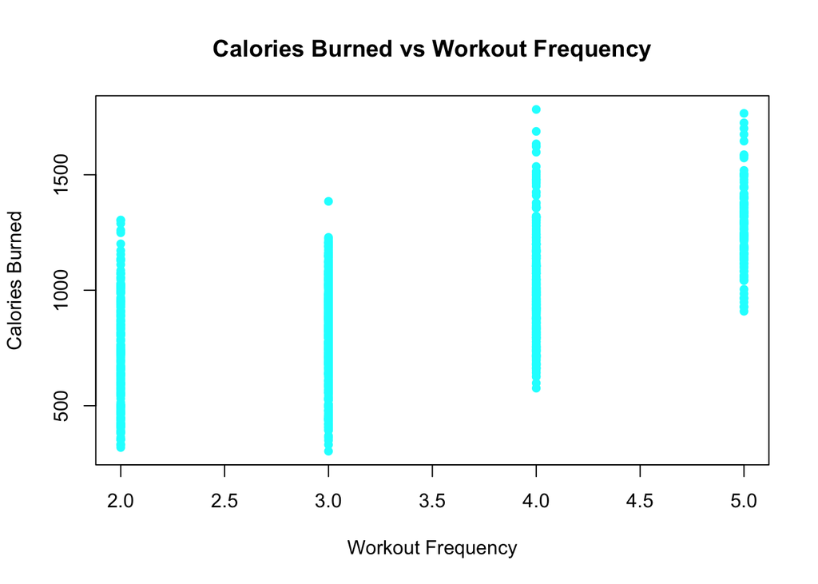

```r
plot(gymData$Workout_Frequency, gymData$Calories_Burned,
     main="Calories Burned vs Workout Frequency",
     xlab="Workout Frequency", ylab="Calories Burned", col="cyan", pch=16)
```

```r
gymLM <- lm(Calories_Burned ~ Workout_Frequency, data=gymData)
summary(gymLM)
```

```
##
## Call:
## lm(formula = Calories_Burned ~ Workout_Frequency, data = gymData)
##
## Residuals:
##     Min      1Q  Median      3Q     Max
## -547.08 -164.04  -11.12  147.88  760.88
##
## Coefficients:
##                   Estimate Std. Error t value Pr(>|t|)
## (Intercept)        333.953     26.981   12.38   <2e-16 ***
## Workout_Frequency  172.042      7.832   21.96   <2e-16 ***
## ---
## Signif. codes:  0 '***' 0.001 '**' 0.01 '*' 0.05 '.' 0.1 ' ' 1
##
## Residual standard error: 223 on 971 degrees of freedom
## Multiple R-squared:  0.3319, Adjusted R-squared:  0.3313
## F-statistic: 482.5 on 1 and 971 DF,  p-value: < 2.2e-16
```